# trimmedAMKE_probability of nest failure

Andrew East

2025-09-24

```r
library(tidyverse)
library(knitr)
library(jagsUI)
library(DiagrammeR)
set.seed(1019)
```

Seed is set to 1019 for reproducibility.

# Data

Manual data, pen-wise, inclusive of multiple broods.

```r
dflongforcount <- data.frame(
  dose=factor(c(rep("cont",6),rep("low",7),rep("med",6),rep("high",8)),
              levels=c("cont","low","med","high")),
  dosenum=c(rep(0.000121,6),rep(0.121,7),rep(0.45,6),rep(2.04,8)),
  pen=c(31,32,33,34,35,35,36,37,38,38,39,40,40,41,42,43,43,44,45,46,46,46,47,48,48,48,50),
  clutch=c(1,1,1,1,1,2,1,1,1,2,1,1,2,1,1,1,2,1,1,1,2,3,1,1,2,3,1),
  numhatched=c(3,2,2,1,0,0,4,1,0,3,3,0,0,3,0,0,0,1,1,0,0,0,2,0,0,0,2)
)

dflongforcount$failure <- ifelse(dflongforcount$numhatched==0,1,0)
```

# JAGS setup and run of Poisson GLM

```r
jags.data <- list(y=dflongforcount$numhatched,
                  conc=dflongforcount$dosenum,
                  n=nrow(dflongforcount))

cat(file="model_AMKE_poisson_eggs hatched by normal dose.txt","
  model{
  #priors and linear models
  alpha ~ dnorm(log(3),100) # mean and precision in jags precision is inverse of the variance, so 1/sigma^2 and in this case suggests the priors are mean=0, sd=0.1 (exp(0.1) on the real scale) (sqrt(1/100))
  beta ~ dnorm(0,0.001)

  #likelihood for the poisson GLM
  for(i in 1:n){
    y[i] ~ dpois(lambda[i]) #stochastic
    log(lambda[i]) <- alpha + beta * conc[i]
  }
  mean.exp.count <- exp(alpha)
}
")

inits <- function(){list(alpha=rnorm(1,0,1),beta=rnorm(1,0,1))}

parameters <- c("alpha","beta","mean.exp.count","lambda")

ni <- 50000
nb <- 10000
nc <- 3
nt <- 10
na <- 1000

out1 <- jags(jags.data, inits, parameters, "model_AMKE_poisson_eggs hatched by normal dose.txt", n.iter=ni, n.burnin=nb, n.chains=nc, n.thin=nt, n.adapt=na, parallel=T)
```

```
##
## Processing function input.......
##
## Done.
##
## Beginning parallel processing using 3 cores. Console output will be suppressed.
##
## Parallel processing completed.
##
## Calculating statistics.......
##
## Done.
```

```r
test <- data.frame(out1$sims.list[1:2])
#write_csv(test, "out1posterioralphaandbeta.csv")
```

## JAGS output wrangling for Poisson GLM

```r
contm <- out1$mean$lambda[1] #2.575
lowm <- out1$mean$lambda[7] #2.264
medm <- out1$mean$lambda[14] #1.605
highm <- out1$mean$lambda[20] #0.343

contl <- out1$q2.5$lambda[1] #2.164
lowl <- out1$q2.5$lambda[7] #1.906
medl <- out1$q2.5$lambda[14] #1.181
highl <- out1$q2.5$lambda[20] #0.081

contu <- out1$q97.5$lambda[1] #3.041
lowu <- out1$q97.5$lambda[7] #2.66
medu <- out1$q97.5$lambda[14] #2.034
highu <- out1$q97.5$lambda[20] #0.812


### probability of having a certain number of viable eggs

counteggdf <- data.frame(
  dose=c(0.000121, 0.121, 0.45, 2.04),
  mean=c(contm, lowm, medm, highm),
  lower=c(contl, lowl, medl, highl),
  upper=c(contu, lowu, medu, highu)
)

effectzerodf <- data.frame(
  dose=c(0.000121, 0.121, 0.45, 2.04),
  mean=c(dpois(0, lambda=contm),dpois(0, lambda=lowm),dpois(0, lambda=medm),dpois(0, lambda=highm)),
  lower=c(dpois(0, lambda=contl),dpois(0, lambda=lowl),dpois(0, lambda=medl),dpois(0, lambda=highl)),
  upper=c(dpois(0, lambda=contu),dpois(0, lambda=lowu),dpois(0, lambda=medu),dpois(0, lambda=highu)),
  hatchedeggs=rep(0,4)
)

effect3df <- data.frame(
  dose=c(0.000121, 0.121, 0.45, 2.04),
  mean=c(dpois(3, lambda=contm),dpois(3, lambda=lowm),dpois(3, lambda=medm),dpois(3, lambda=highm)),
  lower=c(dpois(3, lambda=contl),dpois(3, lambda=lowl),dpois(3, lambda=medl),dpois(3, lambda=highl)),
  upper=c(dpois(3, lambda=contu),dpois(3, lambda=lowu),dpois(3, lambda=medu),dpois(3, lambda=highu)),
  hatchedeggs=rep(3,4)
)

effect2df <- data.frame(
  dose=c(0.000121, 0.121, 0.45, 2.04),
  mean=c(dpois(2, lambda=contm),dpois(2, lambda=lowm),dpois(2, lambda=medm),dpois(2, lambda=highm)),
  lower=c(dpois(2, lambda=contl),dpois(2, lambda=lowl),dpois(2, lambda=medl),dpois(2, lambda=highl)),
  upper=c(dpois(2, lambda=contu),dpois(2, lambda=lowu),dpois(2, lambda=medu),dpois(2, lambda=highu)),
  hatchedeggs=rep(2,4)
)

effect5df <- data.frame(
  dose=c(0.000121, 0.121, 0.45, 2.04),
  mean=c(dpois(5, lambda=contm),dpois(5, lambda=lowm),dpois(5, lambda=medm),dpois(5, lambda=highm)),
  lower=c(dpois(5, lambda=contl),dpois(5, lambda=lowl),dpois(5, lambda=medl),dpois(5, lambda=highl)),
  upper=c(dpois(5, lambda=contu),dpois(5, lambda=lowu),dpois(5, lambda=medu),dpois(5, lambda=highu)),
  hatchedeggs=rep(5,4)
)

effect1df <- data.frame(
  dose=c(0.000121, 0.121, 0.45, 2.04),
  mean=c(dpois(1, lambda=contm),dpois(1, lambda=lowm),dpois(1, lambda=medm),dpois(1, lambda=highm)),
  lower=c(dpois(1, lambda=contl),dpois(1, lambda=lowl),dpois(1, lambda=medl),dpois(1, lambda=highl)),
  upper=c(dpois(1, lambda=contu),dpois(1, lambda=lowu),dpois(1, lambda=medu),dpois(1, lambda=highu)),
  hatchedeggs=rep(1,4)
)

effect4df <- data.frame(
  dose=c(0.000121, 0.121, 0.45, 2.04),
  mean=c(dpois(4, lambda=contm),dpois(4, lambda=lowm),dpois(4, lambda=medm),dpois(4, lambda=highm)),
  lower=c(dpois(4, lambda=contl),dpois(4, lambda=lowl),dpois(4, lambda=medl),dpois(4, lambda=highl)),
  upper=c(dpois(4, lambda=contu),dpois(4, lambda=lowu),dpois(4, lambda=medu),dpois(4, lambda=highu)),
  hatchedeggs=rep(4,4)
)

bigeggprobdf <- rbind(
  effectzerodf,
  effect1df,
  effect2df,
  effect3df,
  effect4df,
  effect5df
)
```

# Table of Poisson GLM output

Probability of having a certain number of hatched eggs at each dose with confidence intervals.  
Note that upper and lower are strange because some dose response are decreasing and some are increasing depending on the number of hatched eggs.

```r
bigeggprobdf |>
  #filter(hatchedeggs==0)|>
  kable(, digits=5)
```

| dose | mean | lower | upper | hatchedeggs |
| --- | --- | --- | --- | --- |
| 0.00012 | 0.07615 | 0.11519 | 0.04752 | 0 |
| 0.12100 | 0.10421 | 0.14819 | 0.06999 | 0 |
| 0.45000 | 0.20227 | 0.30665 | 0.13041 | 0 |
| 2.04000 | 0.71318 | 0.92599 | 0.44442 | 0 |
| 0.00012 | 0.19609 | 0.24894 | 0.14477 | 1 |
| 0.12100 | 0.23566 | 0.28293 | 0.18614 | 1 |
| 0.45000 | 0.32326 | 0.36247 | 0.26566 | 1 |
| 2.04000 | 0.24107 | 0.07120 | 0.36042 | 1 |
| 0.00012 | 0.25247 | 0.26901 | 0.22053 | 2 |
| 0.12100 | 0.26645 | 0.27010 | 0.24750 | 2 |
| 0.45000 | 0.25831 | 0.21423 | 0.27058 | 2 |
| 2.04000 | 0.04074 | 0.00274 | 0.14615 | 2 |
| 0.00012 | 0.21671 | 0.19379 | 0.22396 | 3 |
| 0.12100 | 0.20084 | 0.17190 | 0.21940 | 3 |
| 0.45000 | 0.13761 | 0.08441 | 0.18373 | 3 |
| 2.04000 | 0.00459 | 0.00007 | 0.03951 | 3 |
| 0.00012 | 0.13951 | 0.10470 | 0.17058 | 4 |
| 0.12100 | 0.11354 | 0.08205 | 0.14586 | 4 |
| 0.45000 | 0.05498 | 0.02495 | 0.09357 | 4 |
| 2.04000 | 0.00039 | 0.00000 | 0.00801 | 4 |
| 0.00012 | 0.07185 | 0.04526 | 0.10394 | 5 |
| 0.12100 | 0.05135 | 0.03133 | 0.07758 | 5 |
| 0.45000 | 0.01757 | 0.00590 | 0.03812 | 5 |
| 2.04000 | 0.00003 | 0.00000 | 0.00130 | 5 |

# Interpolate adverse increase in probability of nest failure using Poisson GLM

## Background probability of having zero hatched eggs

```r
dpois(0,lambda=contm)
```

```
## [1] 0.07614831
```

## 0.2 added risk of having zero hatched eggs

```r
dpois(0,lambda=contm)+0.2
```

```
## [1] 0.2761483
```

## Highest concentration where probability of having zero eggs is <0.28

i.e. “safe” concentration

```r
### do prediction interpolation for having zero

alt.conc.pred <- seq(from=0.0001,to=3, length.out=1000)
pred2 <- array(NA,dim=c(length(alt.conc.pred),12000))
for(i in 1:12000){
  pred2[,i] <- exp(out1$sims.list$alpha[i]+out1$sims.list$beta[i]*alt.conc.pred)
}

pm2 <- apply(pred2,1, mean)
pm2l <- apply(pred2,1, quantile, probs=0.975)
pm2u <- apply(pred2,1, quantile, probs=0.025)

prob <- apply(pred2, 1, function(x) mean((x-1)<0))

dprob0 <- apply(pred2,1,function(x) mean(dpois(0,lambda=x)))
dprob0min <- apply(pred2,1,function(x) quantile(dpois(0,lambda=x), probs=0.05))
dprob0max <- apply(pred2,1,function(x) quantile(dpois(0,lambda=x), probs=0.95))

#plot(dprob0~alt.conc.pred, ylim=c(0,1))
#points(dprob0min~alt.conc.pred, col="darkgray")
#points(dprob0max~alt.conc.pred, col="darkgray")


mintwentythreshold <- max(alt.conc.pred[dprob0min<0.28])
maxtwentythreshold <- max(alt.conc.pred[dprob0max<0.28])
meantwentythreshold <- max(alt.conc.pred[dprob0<0.28])
mintwentythreshold
```

```
## [1] 1.090154
```

```r
meantwentythreshold
```

```
## [1] 0.648727
```

```r
maxtwentythreshold
```

```
## [1] 0.432518
```

## Plot of predicted number of eggs

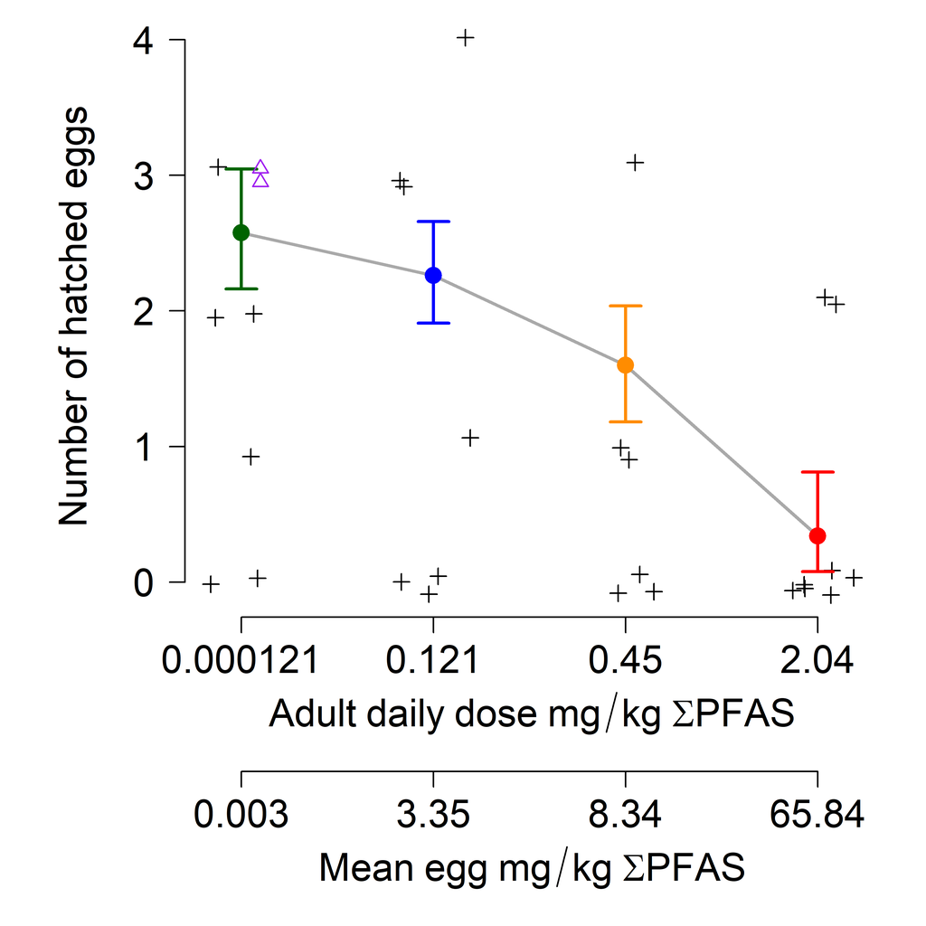

```r
par(mai=c(2,1.2,0.1,0.3))
plot(jitter(numhatched, 0.5)~jitter(as.numeric(factor(dose))), data=dflongforcount, pch=3, ylab="Number of hatched eggs", xlab=expression(Adult~daily~dose~mg/kg~Sigma*PFAS),
     bty="n", las=1, axes=F, cex.lab=1.5)
axis(1, at=c(1,2,3,4), labels=c("0.000121", "0.121", "0.45", "2.04"), font=1, cex.axis=1.5)
axis(2, at=c(0,1,2,3,4), labels=c(0,1,2,3,4), font=1, las=1, cex.axis=1.5)
arrows(as.numeric(factor(counteggdf$dose)),counteggdf$lower,as.numeric(factor(counteggdf$dose)),counteggdf$upper, lwd=2, length=0.1, angle=90, code=3, col=c("darkgreen","blue","darkorange","red"))
points(mean~as.numeric(factor(dose)), data=counteggdf, type="l", col="darkgray", lwd=2)
points(mean~as.numeric(factor(dose)), data=counteggdf, type="p", col=c("darkgreen","blue","darkorange","red"), pch=16, cex=1.5)
points(c(1.1,1.1),c(2.95,3.05),col="purple", pch=2)
axis(1, at=c(1,2,3,4), labels=c("0.003", "3.35", "8.34", "65.84"), font=1, cex.axis=1.5, line=5)
mtext(expression(Mean~egg~mg/kg~Sigma*PFAS), side=1, line=8, font=1, cex=1.5)
```

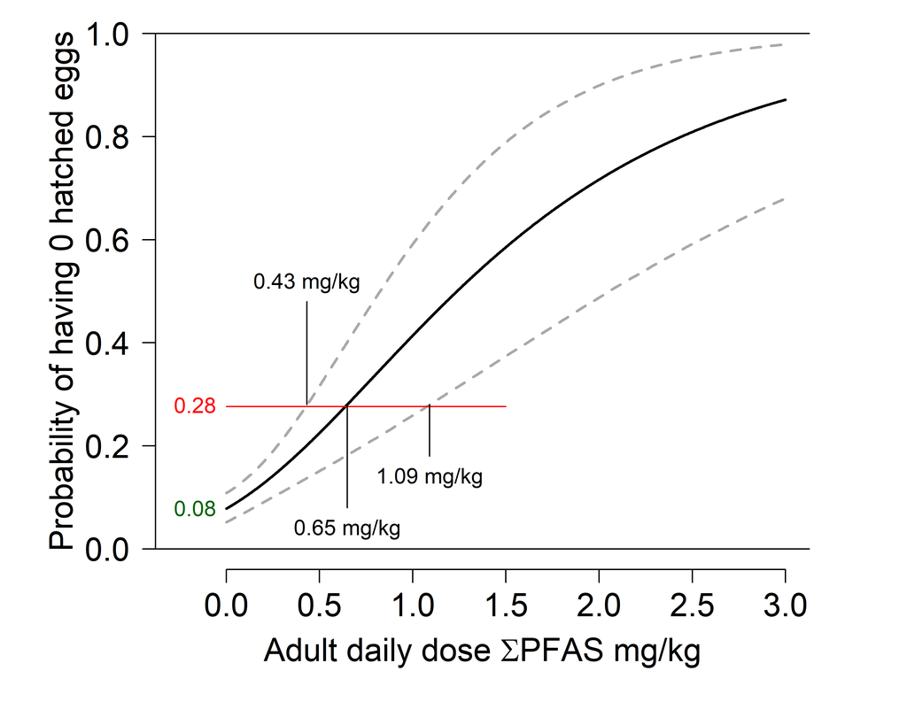

```r
par(mai=c(1.2,1.2,0.1,0.75))
plot(dprob0~alt.conc.pred, log="", ylim=c(0,1), type="l", bty="n", xlim=c(-0.25,3),
     ylab="Probability of having 0 hatched eggs", xlab=expression(paste("Adult daily dose ", Sigma,"PFAS mg/kg")), las=1,
     font=1, font.lab=1, pch=16, cex=2, lwd=2, cex.lab=1.5, cex.axis=1.5)
points(dprob0min~alt.conc.pred, type="l", lty=2, col="darkgray", lwd=2)
points(dprob0max~alt.conc.pred, type="l", lty=2, col="darkgray", lwd=2)
abline(h=c(0,1))
text(-0.35,dpois(0,lambda=contm),"0.08", pos=4, col="darkgreen")
text(-0.35,dpois(0,lambda=contm)+0.2,"0.28", pos=4, col="red")
segments(0,dpois(0,lambda=contm)+0.2,1.5,dpois(0,lambda=contm)+0.2, col="red")
segments(0.432518,0.28,0.432518,0.48, col="black")
#text(0.432518,0.48,"0.43 mg/kg\nP(0 eggs)<0.28", pos=3, col="black")
text(0.432518,0.48,"0.43 mg/kg", pos=3, col="black")
segments(1.090154,0.28,1.090154,0.18, col="black")
#text(1.090154,0.18,"1.09 mg/kg\nP(0 eggs)<0.28", pos=1, col="black", xpd=NA)
text(1.090154,0.18,"1.09 mg/kg", pos=1, col="black", xpd=NA)
segments(0.648727,0.28,0.648727,0.08, col="black")
text(0.648727,0.08,"0.65 mg/kg", pos=1, col="black", xpd=NA)
```

# JAGS setup and run of Bernoulli GLM

```r
jags.data2 <- list(y=dflongforcount$failure,
                  conc=dflongforcount$dosenum,
                  n=nrow(dflongforcount))

cat(file="model_AMKE_bernoulli_eggs hatched by normal dose.txt","
  model{
  #priors and linear models
  alpha <- logit(mean.theta)
  mean.theta ~ dunif(0,0.5)
  beta ~ dnorm(0,0.001)

  #likelihood for the bernoulli GLM
  for(i in 1: n){
    y[i] ~ dbern(theta[i]) #stochastic
    logit(theta[i]) <- alpha + beta * conc[i]
  }
}
")

inits2 <- function(){list(mean.theta=runif(1,0, 0.5),beta=rnorm(1,0,1))}

parameters2 <- c("alpha","beta","mean.theta","theta")

ni <- 50000
nb <- 10000
nc <- 3
nt <- 10
na <- 1000

out2 <- jags(jags.data2, inits2, parameters2, "model_AMKE_bernoulli_eggs hatched by normal dose.txt", n.iter=ni, n.burnin=nb, n.chains=nc, n.thin=nt, n.adapt=na, parallel=T)
```

```
##
## Processing function input.......
##
## Done.
##
## Beginning parallel processing using 3 cores. Console output will be suppressed.
##
## Parallel processing completed.
##
## Calculating statistics.......
##
## Done.
```

```r
#jagsUI::traceplot(out2)

test2 <- data.frame(out2$sims.list[1:2])
#write_csv(test, "out1posterioralphaandbeta.csv")
```

$$\alpha \sim \text{Uniform}(0,0.5)\\
\beta \sim N(0,31.62)\\
y \sim \text{Bernoulli}(\theta)\\
logit(\theta) = alpha + \beta \sum PFAS$$

## JAGS output wrangling for Bernoulli GLM

```r
contb <- out2$mean$theta[1]
lowb <- out2$mean$theta[7]
medb <- out2$mean$theta[14]
highb <- out2$mean$theta[21]

contbl <- out2$q2.5$theta[1]
lowbl <- out2$q2.5$theta[7]
medbl <- out2$q2.5$theta[14]
highbl <- out2$q2.5$theta[21]

contbu <- out2$q97.5$theta[1]
lowbu <- out2$q97.5$theta[7]
medbu <- out2$q97.5$theta[14]
highbu <- out2$q97.5$theta[21]

### probability of a failed nest (having zero hatched eggs)

failuredf <- data.frame(
  dose=c(0.000121, 0.121, 0.45, 2.04),
  mean=c(contb, lowb, medb, highb),
  lower=c(contbl, lowbl, medbl, highbl),
  upper=c(contbu, lowbu, medbu, highbu)
)



# plot(jitter(dflongforcount$failure, 0.2)~jitter(as.numeric(factor(dflongforcount$dosenum)),0.5), axes=F, pch=3, ylab="Per nest probability of failure", xlab="Diet concentration (mg/kg-d sumPFAS)", )
# lines(as.numeric(factor(dflongforcount$dosenum)), out2$mean$theta, col="blue", lwd=3)
# lines(as.numeric(factor(dflongforcount$dosenum)), out2$q2.5$theta, lwd=3, lty=2)
# lines(as.numeric(factor(dflongforcount$dosenum)), out2$q97.5$theta, lwd=3, lty=2)
# axis(1,at=unique(as.numeric(factor(dflongforcount$dosenum))), labels=sort(unique(round(dflongforcount$dosenum,2))))
# axis(2,las=1)
```

## Plot of predicted probability of failure (zero hatched eggs)

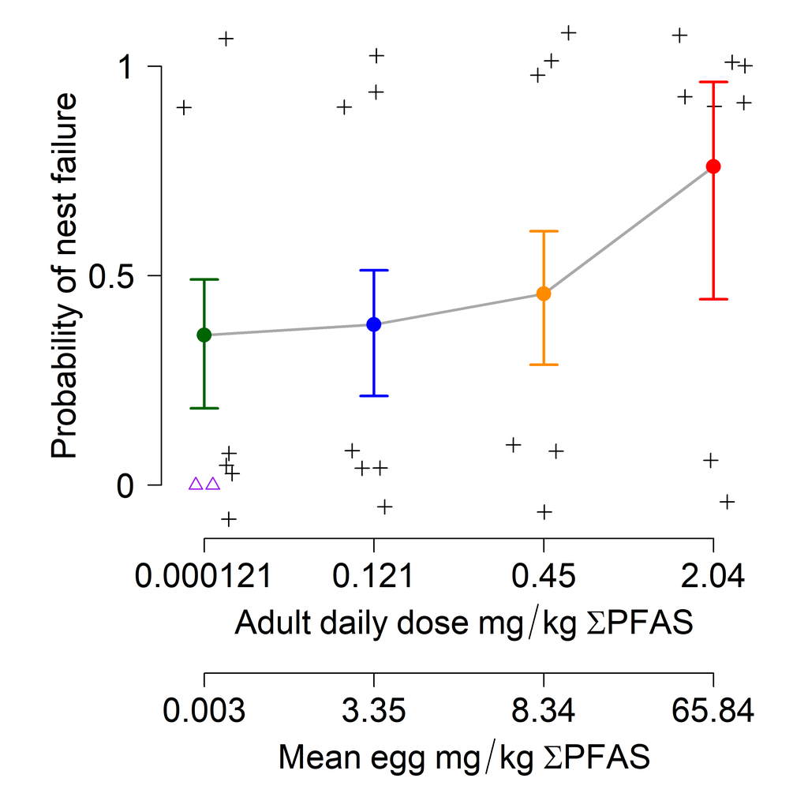

```r
par(mai=c(2,1.2,0.1,0.3))
plot(jitter(failure, 0.5)~jitter(as.numeric(factor(dose))), data=dflongforcount, pch=3, ylab="Probability of nest failure", xlab=expression(Adult~daily~dose~mg/kg~Sigma*PFAS),
     bty="n", las=1, axes=F, cex.lab=1.5)
axis(1, at=c(1,2,3,4), labels=c("0.000121", "0.121", "0.45", "2.04"), font=1, cex.axis=1.5)
axis(2, at=c(0,0.5,1), labels=c(0,0.5,1), font=1, las=1, cex.axis=1.5)
arrows(as.numeric(factor(failuredf$dose)),failuredf$lower,as.numeric(factor(failuredf$dose)),failuredf$upper, lwd=2, length=0.1, angle=90, code=3, col=c("darkgreen","blue","darkorange","red"))
points(mean~as.numeric(factor(dose)), data=failuredf, type="l", col="darkgray", lwd=2)
points(mean~as.numeric(factor(dose)), data=failuredf, type="p", col=c("darkgreen","blue","darkorange","red"), pch=16, cex=1.5)
points(c(0.95,1.05),c(0,0),col="purple", pch=2)
axis(1, at=c(1,2,3,4), labels=c("0.003", "3.35", "8.34", "65.84"), font=1, cex.axis=1.5, line=5)
mtext(expression(Mean~egg~mg/kg~Sigma*PFAS), side=1, line=8, font=1, cex=1.5)
```

# Interpolate adverse increase in probability of nest failure using Bernoulli GLM

## Background probability of having zero hatched eggs

```r
dbinom(1,1,prob=contb)
```

```
## [1] 0.3577885
```

## 0.2 added risk of having zero hatched eggs

```r
dbinom(1,1,prob=contb)+0.2
```

```
## [1] 0.5577885
```

i.e. “safe” concentration

```r
### do prediction interpolation for having zero

alt.conc.pred <- seq(from=0.0001,to=3, length.out=1000)
pred3 <- array(NA,dim=c(length(alt.conc.pred),12000))
for(i in 1:12000){
  pred3[,i] <- plogis(out2$sims.list$alpha[i]+out2$sims.list$beta[i]*alt.conc.pred)
}

pm3 <- apply(pred3,1, mean)
pm3l <- apply(pred3,1, quantile, probs=0.975)
pm3u <- apply(pred3,1, quantile, probs=0.025)

prob2 <- apply(pred3, 1, function(x) mean((x-1)<0))

dprob02 <- apply(pred3,1,function(x) mean(dbinom(1,1,prob=x)))
dprob02min <- apply(pred3,1,function(x) quantile(dbinom(1,1,prob=x), probs=0.05))
dprob02max <- apply(pred3,1,function(x) quantile(dbinom(1,1,prob=x), probs=0.95))

#plot(dprob0~alt.conc.pred, ylim=c(0,1))
#points(dprob0min~alt.conc.pred, col="darkgray")
#points(dprob0max~alt.conc.pred, col="darkgray")


mintwentythreshold2 <- max(alt.conc.pred[dprob02min<0.5579766])
maxtwentythreshold2 <- max(alt.conc.pred[dprob02max<0.5579766])
meantwentythreshold2 <- max(alt.conc.pred[dprob02<0.5579766])
mintwentythreshold2
```

```
## [1] 2.915919
```

```r
meantwentythreshold2
```

```
## [1] 0.8919622
```

```r
maxtwentythreshold2
```

[output not shown]

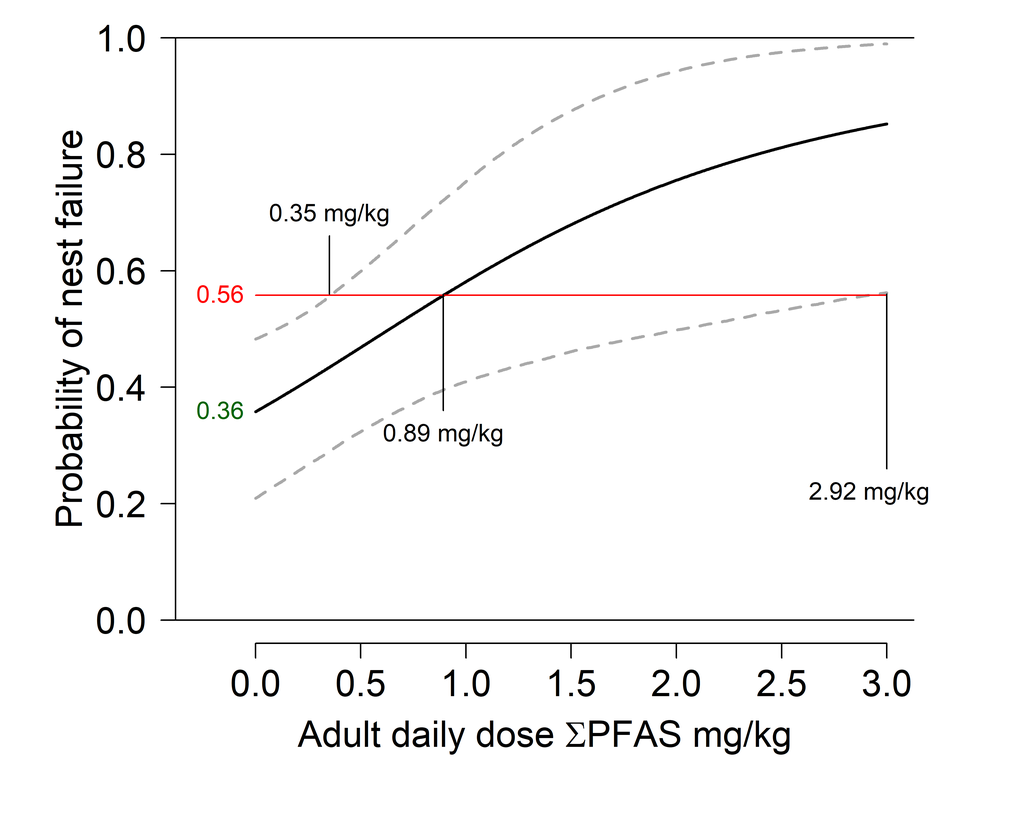

```r
par(mai=c(1.2,1.2,0.1,0.75))
plot(dprob02~alt.conc.pred, log="", ylim=c(0,1), type="l", bty="n", xlim=c(-0.25,3),
     ylab="Probability of nest failure", xlab=expression(paste("Adult daily dose ", Sigma,"PFAS mg/kg")), las=1,
     font=1, font.lab=1, pch=16, cex=2, lwd=2, cex.lab=1.5, cex.axis=1.5)
points(dprob02min~alt.conc.pred, type="l", lty=2, col="darkgray", lwd=2)
points(dprob02max~alt.conc.pred, type="l", lty=2, col="darkgray", lwd=2)
abline(h=c(0,1))
text(-0.35,dbinom(1,1,prob=contb),"0.36", pos=4, col="darkgreen")
text(-0.35,dbinom(1,1,prob=contb)+0.2,"0.56", pos=4, col="red")
segments(0,dbinom(1,1,prob=contb)+0.2,3,dbinom(1,1,prob=contb)+0.2, col="red")
segments(0.3514396,0.56,0.3514396,0.66, col="black")
text(0.3514396,0.66,"0.35 mg/kg", pos=3, col="black")
segments(3,0.56,3,0.26, col="black")
text(2.915919,0.26,"2.92 mg/kg", pos=1, col="black", xpd=NA)
segments(0.8919622,0.56,0.8919622,0.36, col="black")
text(0.8919622,0.36,"0.89 mg/kg", pos=1, col="black", xpd=NA)
```

# Stochastic population trajectories

## Simple model diagram

```r
mermaid("
  graph RL
    A(Adult);
    J(Juvenile);
    I(Immigration);

    A--Fecundity-->J;
    A--Adult Survival-->A;
    J--Juvenile Survival-->A;
    I-->A;
",
width=500, height=500)
```

[interactive chart not shown]

## Build distributions for demographic rates

Survival and immigration rates from McClure et al. 2021. McClure CJW et al. 2021. Demography of a widespread raptor across disparate regions. Ibis. 163(2):658–670 https://doi.org/10.1111/ibi.12916

### Juvenile survival

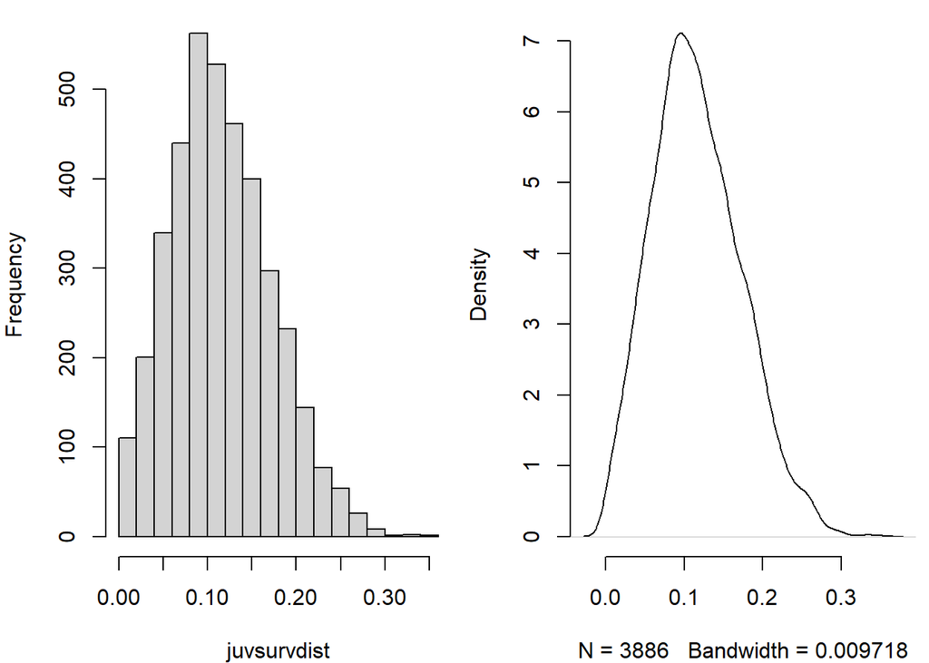

```r
juvsurvdist <- c(
  rnorm(1000, mean=0.13, sd=0.06),
  rnorm(1000, mean=0.15, sd=0.05),
  rnorm(1000, mean=0.09, sd=0.03),
  rnorm(1000, mean=0.08, sd=0.06)
)
juvsurvdist <- juvsurvdist[!juvsurvdist<0]
par(mfrow=c(1,2),mai=c(0.8,0.8,0.1,0.1))
hist(juvsurvdist, main="")
plot(density(juvsurvdist), main="",bty="n")
```

```r
par(mfrow=c(1,1),mai=c(1,1,0.5,0.5))
summary(juvsurvdist)
```

```
##      Min.   1st Qu.    Median      Mean   3rd Qu.      Max.
## 0.0003585 0.0756261 0.1106364 0.1159136 0.1525845 0.3493614
```

```r
sd(juvsurvdist)
```

```
## [1] 0.05639346
```

#### Juvenile survival variability

Across the populations.

```r
sd(c(0.13, 0.15, 0.09, 0.08))
```

```
## [1] 0.03304038
```

### Adult survival

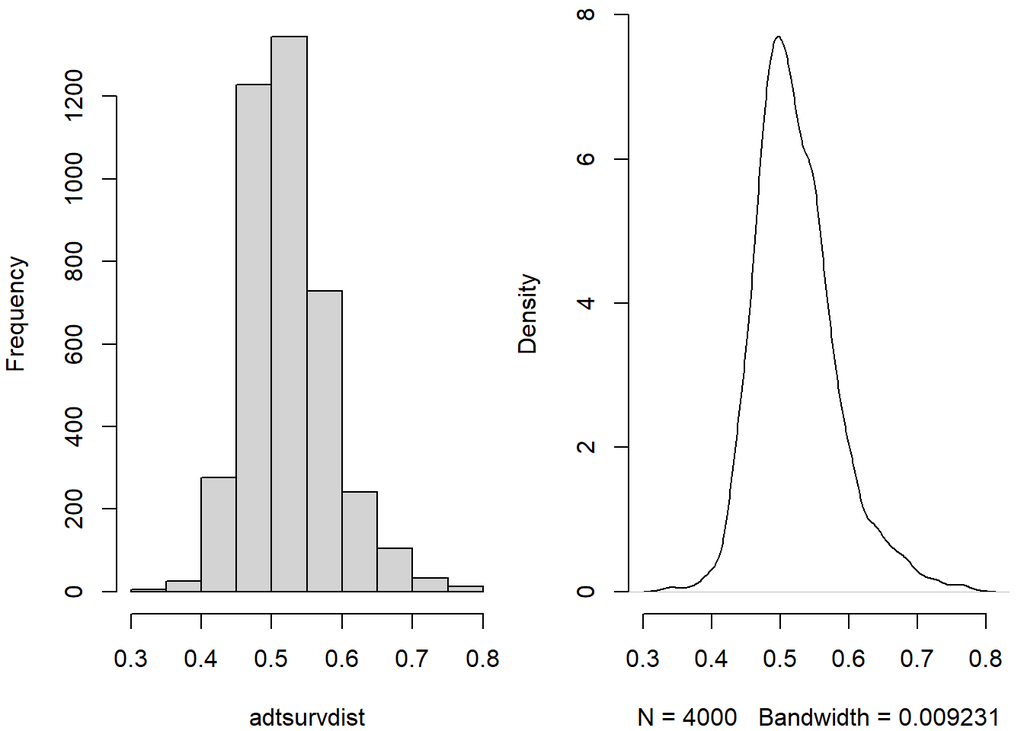

```r
adtsurvdist <- c(
  rnorm(1000, mean=0.50, sd=0.03),
  rnorm(1000, mean=0.48, sd=0.03),
  rnorm(1000, mean=0.55, sd=0.03),
  rnorm(1000, mean=0.56, sd=0.08)
)
#adtsurvdist <- adtsurvdist[adtsurvdist>0]
par(mfrow=c(1,2),mai=c(0.8,0.8,0.1,0.1))
hist(adtsurvdist, main="")
plot(density(adtsurvdist), main="",bty="n")
```

```r
par(mfrow=c(1,1),mai=c(1,1,0.5,0.5))
summary(adtsurvdist)
```

```
##    Min. 1st Qu.  Median    Mean 3rd Qu.    Max.
##  0.3272  0.4826  0.5151  0.5229  0.5548  0.7859
```

```r
sd(adtsurvdist)
```

```
## [1] 0.05953504
```

#### Adult survival variability

```r
sd(c(0.50, 0.48, 0.55, 0.56))
```

```
## [1] 0.0386221
```

### Immigration

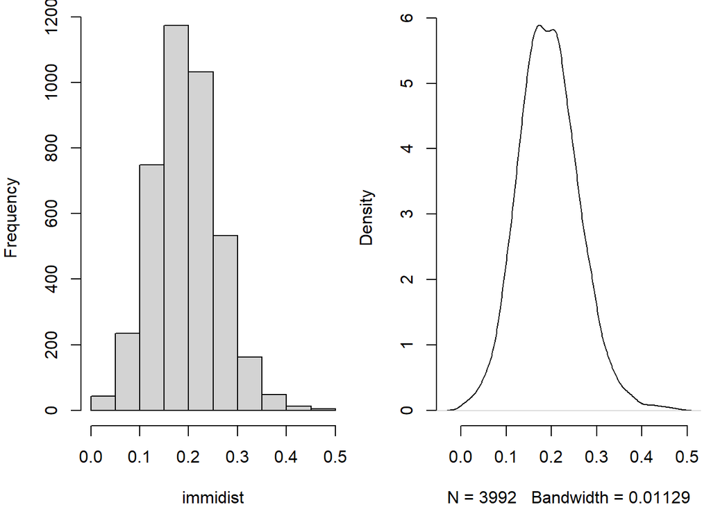

```r
immidist <- c(
  rnorm(1000, mean=0.21, sd=0.06),
  rnorm(1000, mean=0.21, sd=0.05),
  rnorm(1000, mean=0.15, sd=0.04),
  rnorm(1000, mean=0.20, sd=0.09)
)
immidist <- immidist[!immidist<0]
par(mfrow=c(1,2),mai=c(0.8,0.8,0.1,0.1))
hist(immidist, main="")
plot(density(immidist), main="",bty="n")
```

```r
par(mfrow=c(1,1),mai=c(1,1,0.5,0.5))
summary(immidist)
```

```
##     Min.  1st Qu.   Median     Mean  3rd Qu.     Max.
## 0.001566 0.148561 0.191600 0.194103 0.236840 0.474021
```

```r
sd(immidist)
```

```
## [1] 0.06687488
```

#### IMmigration variability

```r
sd(c(0.21, 0.21, 0.15, 0.20))
```

```
## [1] 0.02872281
```

### Fecundity

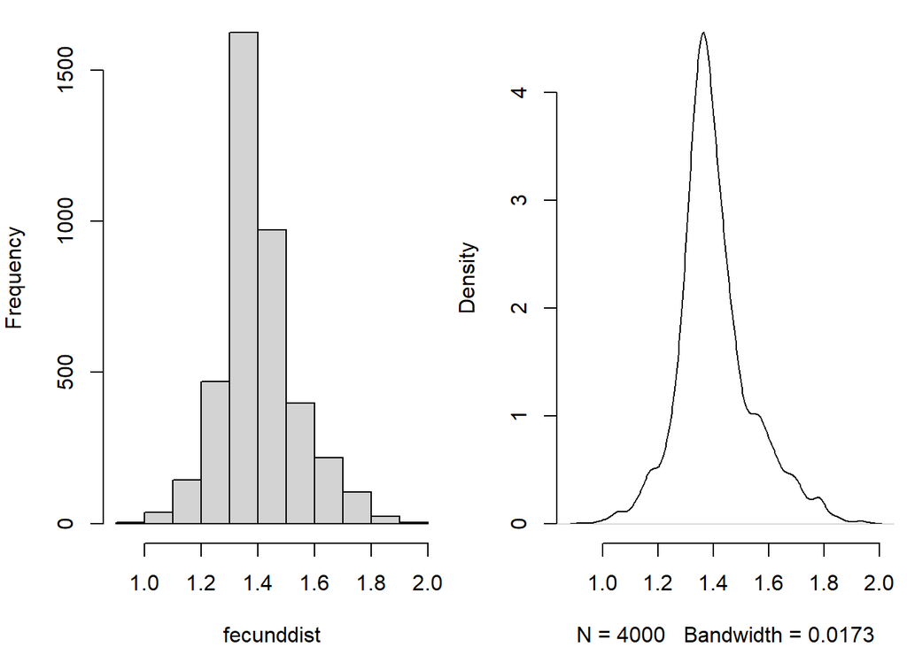

```r
fecunddist <- c(
  rnorm(1000, mean=1.55, sd=0.13),
  rnorm(1000, mean=1.36, sd=0.05),
  rnorm(1000, mean=1.38, sd=0.06),
  rnorm(1000, mean=1.32, sd=0.13)
)
#fecunddist <- fecunddist[!fecunddist<0]
par(mfrow=c(1,2),mai=c(0.8,0.8,0.1,0.1))
hist(fecunddist, main="")
plot(density(fecunddist), main="",bty="n")
```

```r
par(mfrow=c(1,1),mai=c(1,1,0.5,0.5))
summary(fecunddist)
```

```
##    Min. 1st Qu.  Median    Mean 3rd Qu.    Max.
##  0.9304  1.3272  1.3820  1.4032  1.4625  1.9546
```

```r
sd(fecunddist)
```

```
## [1] 0.1328875
```

#### Fecundity variability

```r
sd(c(1.55, 1.36, 1.38, 1.32))
```

```
## [1] 0.1014479
```

## Population simulation setup and runs

```r
# for actual treatment fecundity values
contm2 <- out1$mean$lambda[1] #2.575
lowm2 <- out1$mean$lambda[7] #2.264
medm2 <- out1$mean$lambda[14] #1.605
highm2 <- out1$mean$lambda[20] #0.343

abundanceadt1 <- c(1) # Initial population abundances
abundancejuv1 <- c(0)
simmatcont <- matrix(nrow=10, ncol=100)        # number of years = nrow, number of simulations = ncol
simmatcont[1,] <- sum(abundanceadt1,abundancejuv1)
for(i in 1:100) {
  fecundity <- rpois(1,contm2)*0.5#rnorm(1,0.5,0.15)
  survjuv <- sample(juvsurvdist,1)
  survadt <- sample(adtsurvdist,1)
  immig <- sample(immidist,1)
  abundancejuv <- abundancejuv1
  abundanceadt <- abundanceadt1
  for(j in 2:10) {
    abundancejuv[j] <- abundanceadt[j-1]*survadt*fecundity
    abundanceadt[j] <- abundanceadt[j-1]*survadt+abundancejuv[j-1]*survjuv+immig
    simmatcont[j,i] <- sum(abundancejuv[j],abundanceadt[j])
  }
}
#simmatcont[1:10, 1:10]

simdf1 <- data.frame(simmatcont)               ##make dataframe
simdf1$year <- (1:length(simmatcont[,j]))    ##add year column
simdf1b <- reshape(simdf1, direction="long", idvar="year",varying=list(1:100))   ##turn dataframe into stacked format
#str(simdf1b)
simdf1b$simnumber <- simdf1b$time             ##label nicely
simdf1b$popsize <- simdf1b$X1
simdf1b$treatment <- "Control"

simdf1b$extinct <- ifelse(simdf1b$popsize<1,T,F)
sum(simdf1b$extinct)/NROW(simdf1b$extinct)
```

```
## [1] 0.485
```

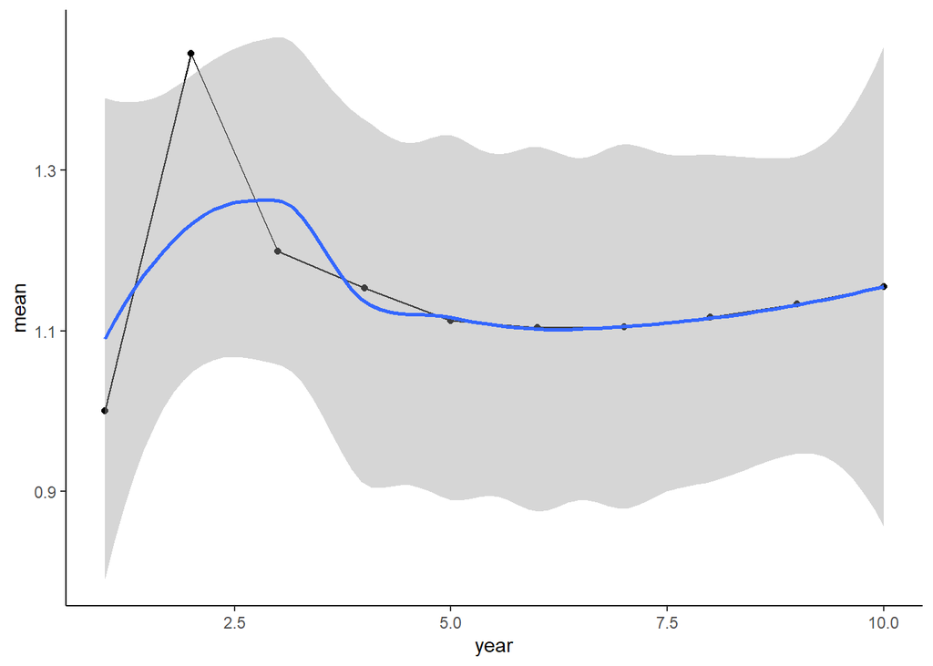

```r
simdf1bsumm <- simdf1b |>
  group_by(year) |>
  summarize(mean=mean(popsize, na.rm=T),
            median=median(popsize, na.rm=T))


ggplot() +
  geom_point(data=simdf1bsumm, aes(x=year, y=mean)) +
  geom_line(data=simdf1bsumm, aes(x=year, y=mean)) +  # add simulation lines to lines from #replicates in exp.
  geom_smooth(data=simdf1bsumm, aes(x=year, y=mean)) +
  theme_classic()
```

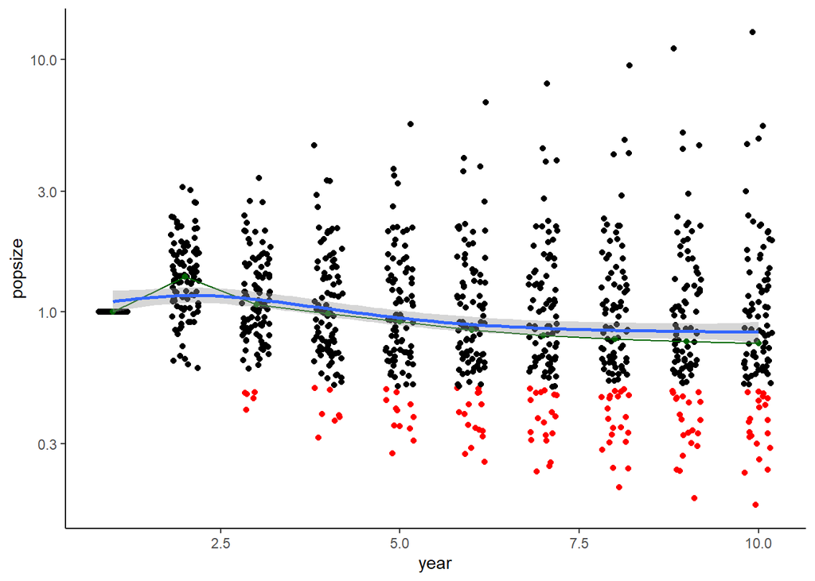

```r
ggplot() +
  geom_jitter(data=simdf1b|>filter(!popsize>=0.5), aes(x=year, y=popsize, group=simnumber), col="red", height=0, width=0.2) +  #
  geom_jitter(data=simdf1b|>filter(popsize>=0.5), aes(x=year, y=popsize, group=simnumber), height=0, width=0.2) +
  geom_point(data=simdf1bsumm, aes(x=year, y=median), color="darkgreen") +
  geom_line(data=simdf1bsumm, aes(x=year, y=median), color="darkgreen") +
  geom_smooth(data=simdf1b, aes(x=year, y=popsize)) +
  scale_y_log10()+
  theme_classic()
```

# trial run using Chapter.Section 3.3 from IPM book

## 3.3 Classical analysis of a matrix population model

### 3.3.

### 3.3.5 Analysis of a matrix population model with different sources of stochasticity and parameter uncertainty

See https://github.com/mikemeredith/IPM_code/blob/main/IPM_03/IPM_03.3.5.R

Code has been modified so “temporal” stochasticity is replaced with “population” stochasticity based on the 4 populations in Mcclure et al. 2021.

#### R stuff to make it happen, borrowed from IPM book package

```r
# https://github.com/kenkellner/IPMbook/blob/main/R/stopifnot.R

stopifnotProbability <- function(arg, allowNA=FALSE) {
  name <- deparse(substitute(arg))
  if(allowNA && all(is.na(arg))) {  # An all-NA vector is logical, but ok.
    # do nothing
  } else {
    if(!allowNA && any(is.na(arg)))
      stop("Argument '", name, "' must not contain NA or NaN.", call.=FALSE)
    if(!is.numeric(arg))
      stop("Argument '", name, "' must be numeric.", call.=FALSE)
    if(any(arg < 0 | arg > 1, na.rm=TRUE)) {
      if(allowNA) {
        stop("Argument '", name, "' must be a probability between 0 and 1, or NA.", call.=FALSE)
      } else {
        stop("Argument '", name, "' must be a probability between 0 and 1.", call.=FALSE)
      }
    }
  }
}

stopifNegative <- function(arg, allowNA=FALSE, allowZero=TRUE) {
  name <- deparse(substitute(arg))
  if(allowNA && all(is.na(arg))) {  # An all-NA vector is logical, but ok.
    # do nothing
  } else {
    if(!allowNA && any(is.na(arg)))
      stop("Argument '", name, "' must not contain NA or NaN.", call.=FALSE)
    if(!is.numeric(arg))
      stop("Argument '", name, "' must be numeric.", call.=FALSE)
    if(allowZero) {
      if(any(arg < 0, na.rm=TRUE)) {
        if(allowNA) {
          stop("Argument '", name, "' must be non-negative, or NA.", call.=FALSE)
        } else {
          stop("Argument '", name, "' must be non-negative.", call.=FALSE)
        }
      }
    } else {
      if(any(arg <= 0, na.rm=TRUE)) {
        if(allowNA) {
          stop("Argument '", name, "' must be greater than 0, or NA.", call.=FALSE)
        } else {
          stop("Argument '", name, "' must be greater than 0.", call.=FALSE)
        }
      }
    }
  }
}

# https://github.com/kenkellner/IPMbook/blob/main/R/stopifnot.R

# https://github.com/kenkellner/IPMbook/blob/main/R/BetaDist.R

getBeta2Par <- function(mean, sd) {
  stopifnotProbability(mean, allowNA=FALSE)
  stopifNegative(sd, allowNA=FALSE, allowZero=FALSE)

  nu <- mean * (1-mean) / sd^2 - 1
  if(any(nu <= 0)) {
    warning("sd is too large; some shape parameters will be NA.", call.=FALSE)
    nu[nu <= 0] <- NA
  }
  alpha <- mean * nu
  beta <- (1-mean) * nu
  cbind(shape1=alpha, shape2=beta)
}

dbeta2 <- function(x, mean, sd) {
  shapes <- getBeta2Par(mean,sd)
  return(dbeta(x, shapes[,1], shapes[,2]))
}

pbeta2 <- function(q, mean, sd, lower.tail=TRUE, log.p=FALSE) {
  shapes <- getBeta2Par(mean,sd)
  return(pbeta(q, shapes[,1], shapes[,2], lower.tail=lower.tail, log.p=log.p))
}
qbeta2 <- function(p, mean, sd, lower.tail=TRUE, log.p=FALSE) {
  shapes <- getBeta2Par(mean,sd)
  return(qbeta(p, shapes[,1], shapes[,2], lower.tail=lower.tail, log.p=log.p))
}

rbeta2 <- function(n, mean, sd) {
  shapes <- getBeta2Par(mean,sd)
  return(rbeta(n, shapes[,1], shapes[,2]))
}

# https://github.com/kenkellner/IPMbook/blob/main/R/BetaDist.R
```

#### Actual simulations

```r
# https://github.com/mikemeredith/IPM_code/blob/main/IPM_03/IPM_03.3.5.R

# 3.3 Classical analysis of a matrix population model
# ===================================================

# 3.3.5 Analysis of a matrix population model with different sources of
#       stochasticity and parameter uncertainty
# ---------------------------------------------------------------------

# Define mean, measurement error and temporal variability of the demographic parameters
mean.sj <- 0.1163615          # Mean value of juv. survival
sd.sj.e <- 0.0554588        # Uncertainty of mean juv. survival as SD on natural scale
sd.sj.t <- plogis(0.03304038)         # population variability of juv. survival as SD on logit scale # Andrew, this might have to be plogis(0.03304038), but not sure, check the text.
mean.sa <- 0.5222         # Mean value of ad. survival
sd.sa.e <- 0.05769693        # Uncertainty of mean ad. survival as SD on natural scale
sd.sa.t <- plogis(0.0386221)         # Temporal variability of ad. survival as SD on logit scale
mean.f1 <- 1.4035          # Mean value of productivity of 1y females
sd.f1.e <- 0.1326032         # Uncertainty of mean productivity as SD on natural scale
sd.f1.t <- 0.1014479          # Temporal variability of productivity as SD on natural scale
mean.fa <- 1.4035          # Mean value of productivity of adult females
sd.fa.e <- 0.1326032         # Uncertainty of mean productivity as SD on natural scale
sd.fa.t <- 0.101          # Temporal variability of productivity as SD on natural scale

# Define the number of years with predictions and the Monte Carlo setting
T <- 10                # Number of years (projection time frame)
nsim <- 1000          # Number of replicate populations simulated

# Define population matrix and initial stage-specific population sizes
N <- array(NA, dim=c(2, T+1, nsim))
N[,1,] <- c(1,3)
r <- matrix(NA, nrow=T, ncol=nsim)
alive <- matrix(NA, nrow=T, ncol=nsim)
mean.r <- numeric(nsim)

# Project population
for (s in 1:nsim){ # Loop over replicate populations
  #if(s %% 100 == 0) {cat(paste("*** Simrep", s, "***\n")) }   # Counter
  # Generate a mean of the demographic rates (subject to measurement error)
  msj <- rbeta2(1, mean.sj, sd.sj.e)
  msa <- rbeta2(1, mean.sa, sd.sa.e)
  mf1 <- rnorm(1, mean.f1, sd.f1.e)
  mfa <- rnorm(1, mean.fa, sd.fa.e)

  # Generate annual demographic rates (subject to temporal variability)
  sj <- plogis(rnorm(T, qlogis(msj), sd.sj.t))
  sa <- plogis(rnorm(T, qlogis(msa), sd.sa.t))
  f1 <- pmax(0, rnorm(T, mf1, sd.f1.t))                       # Avoids negative values
  fa <- pmax(0, rnorm(T, mfa, sd.fa.t))                       # Ditto

  # Project population (include demographic stochasticity)
  for (t in 1:T){                                             # Loop over years
    N[1,t+1,s] <- rpois(1, sj[t] * (f1[t] * N[1,t,s] + fa[t] * N[2,t,s]))
    N[2,t+1,s] <- rbinom(1, sum(N[,t,s]), sa[t])
    if (sum(N[,t+1,s]) == 0) break
    r[t,s] <- log(sum(N[,t+1,s])) - log(sum(N[,t,s]))
    alive[t,s] <- t
  } #t
  #mean.r[s] <- mean(r[min(alive[,s], na.rm=TRUE):max(alive[,s], na.rm=TRUE),s])
}

#mean(mean.r)

#sd(mean.r)


not.extinct <- which(!is.na(alive[T,]))
mean(mean.r[not.extinct])
```

```
## [1] 0
```

```r
sd(mean.r[not.extinct])
```

```
## [1] 0
```

```r
# Extinction probability (after T years)
sum(is.na(alive[T,])) / nsim
```

```
## [1] 0.89
```

```r
rowSums(is.na(alive)) / nsim
```

```
##  [1] 0.042 0.166 0.330 0.501 0.605 0.700 0.782 0.834 0.866 0.890
```

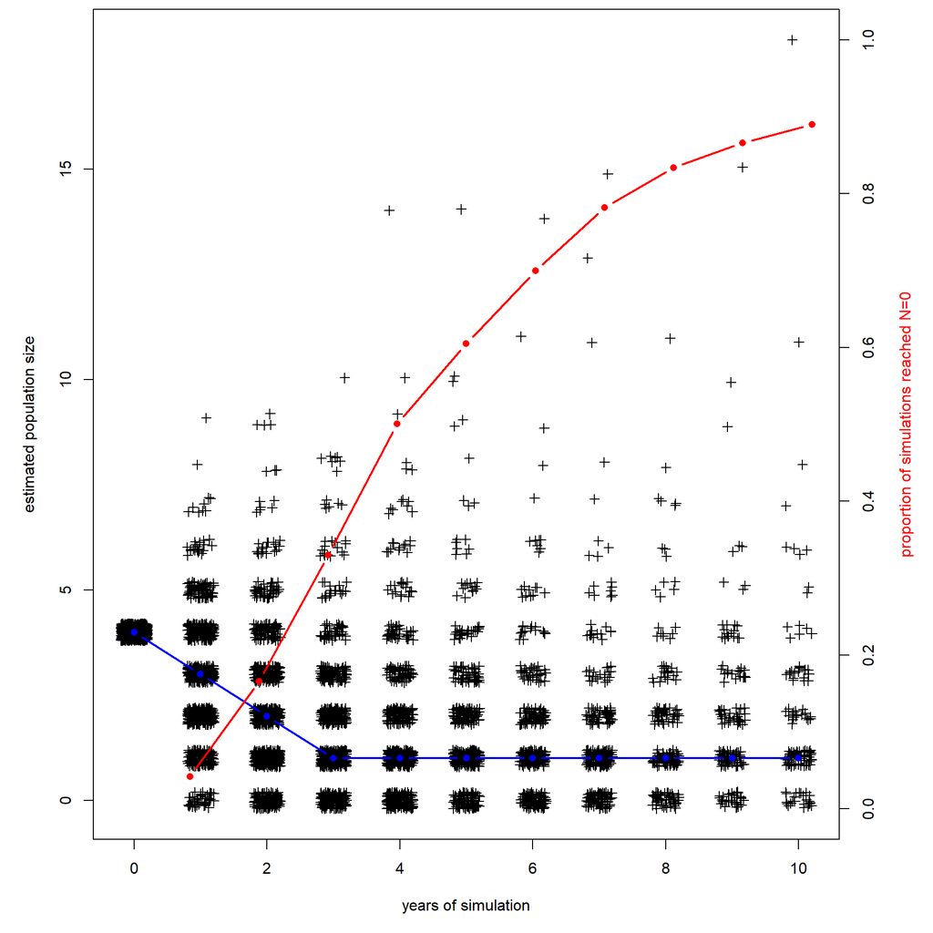

```r
# plot(jitter(c(colSums(N[,,1:nsim])),1)~jitter(rep(c(0:T),nsim),1), pch=3)
# boxplot(c(colSums(N[,,1:nsim]))~factor(rep(c(0:T),nsim)))
 bxpobj<-boxplot(c(colSums(N[,,1:nsim]))~factor(rep(c(0:T),nsim)), plot=F)
# plot(jitter(c(colSums(N[,,1:nsim])),1)~jitter(rep(c(0:T),nsim),1), pch=3)
# points(bxpobj$stats[3,]~c(0:T), type="l", col="red", lwd=2)
#
# par(mai=c(1,1,0.1,1))
# plot(jitter(c(colSums(N[,,1:nsim])),1)~jitter(rep(c(0:T),nsim),1), pch=3)
# points(bxpobj$stats[3,]~c(0:T), type="b", col="blue", lwd=2, pch=16)
# par(new=T)
# plot(c(rowSums(is.na(alive))/nsim)~c(1:T), type="b", col="red", bty="n", xlab="", ylab="", axes=F, ylim=c(0,1), xlim=c(0,T), lwd=2, pch=16)
# axis(side=4, at=pretty(range(c(0,1))))
# mtext("probability of extinction", side=4, line=3)

par(mai=c(1,1,0.1,1))
plot(jitter(c(colSums(N[,,1:nsim])),1)~jitter(rep(c(0:T),nsim),1), pch=3, xlab="years of simulation", ylab="estimated population size")
points(bxpobj$stats[3,]~c(0:T), type="b", col="blue", lwd=2, pch=16)
par(new=T)
plot(c(rowSums(is.na(alive))/nsim)~c(1:T), type="b", col="red", bty="n", xlab="", ylab="", axes=F, ylim=c(0,1), xlim=c(0,T), lwd=2, pch=16)
axis(side=4, at=pretty(range(c(0,1))))
mtext("proportion of simulations reached N=0", side=4, line=3, col="red")
```

```r
# ~~~~ Plot graph with population growth rates (Fig. 3.15)  ~~~~
# op <- par(mar=c(4, 4, 2, 1), las=1, cex=1.1, "mfrow")
# layout(matrix(c(1, 1, 2, 3), 2, 2, byrow=TRUE), widths=c(1, 1), heights=c(1, 1), TRUE)
# plot(r[,1], type="l", lwd=0.5, ylab="Annual population growth rate", xlab="Time",
#     ylim=range(r[which(!is.na(alive))]), col="lightgrey", axes=FALSE)
# axis(1); axis(2)
# for (s in 2:nsim){
#   lines(r[!is.na(alive[,s]),s], lwd=0.5, col="lightgrey")
# }
# lines(apply(r, 1, mean, na.rm=TRUE), lwd=1.5)
# mtext("A", at=0, cex=1.5)
# a <- hist(mean.r, nclass=50, col="dodgerblue", main="",
#     xlab="Population growth rate", axes=FALSE) #xlim=c(-2.5, 0.1),
# axis(1)
# axis(2, at=c(0, 5000, 10000, 15000, 20000, 25000, 30000), labels=c(0, 5, 10, 15, 20, 25, 30))
# mtext("B", at=a$mids[1], cex=1.5)
# a <- hist(mean.r[not.extinct], nclass=25, col="dodgerblue", main="",
#     xlab="Population growth rate", axes=FALSE)
# axis(1)
# axis(2, at=c(0, 2000, 4000, 6000, 8000, 10000), labels=c(0, 2, 4, 6, 8, 10))
# mtext("C", at=a$mids[1], cex=1.5)
# par(op)
# ~~~~~~~~~~~~~~~~~~~~~~~~~~~~~~~~~~~~~~~~~~~~~~~~~~~~~~~~~~~~~~~~~

# https://github.com/mikemeredith/IPM_code/blob/main/IPM_03/IPM_03.3.5.R
```